# Week8 Quiz

```r
data_1 <- read.csv("data1.csv")
data_2 <- read.csv("data2.csv")
library(ggplot2)
```

1.Question 1

The above code block has access to two data frames named data_1 and data_2, both with variables y and x. Here, we use y as the response.

Fit a simple linear regression to both datasets. For both fitted regressions, create a Normal Q-Q plot.

```r
m1 <- lm(y~x, data = data_1)
m2 <- lm(y~x, data = data_2)
```

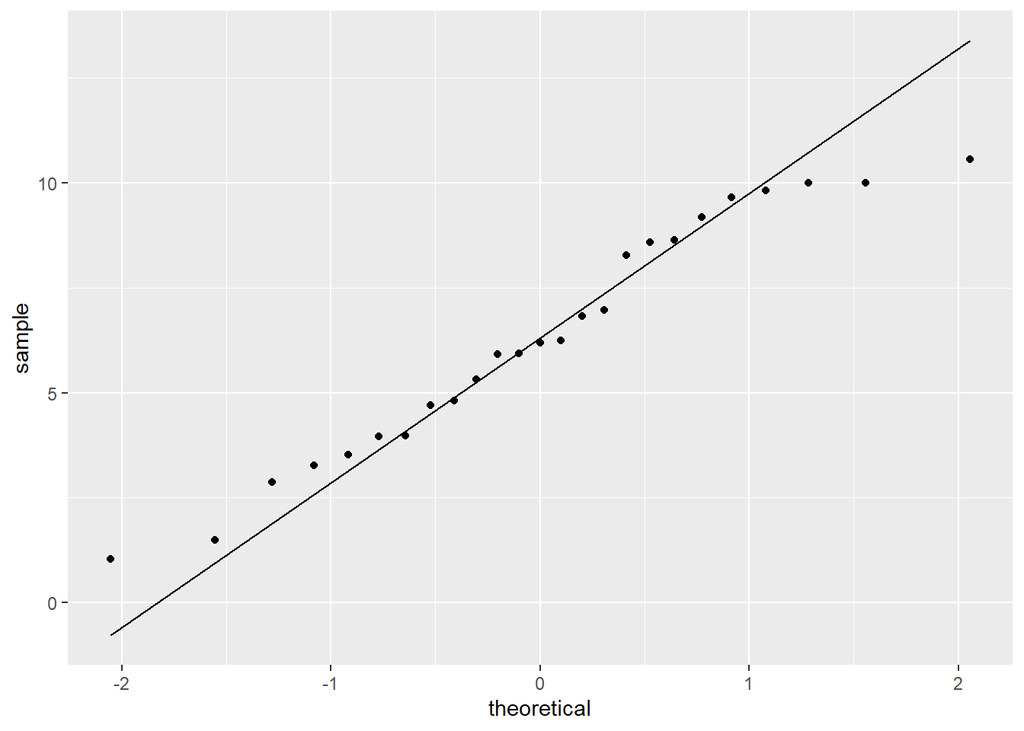

```r
ggplot(data = data_1, aes(sample=y)) + stat_qq() + stat_qq_line()
```

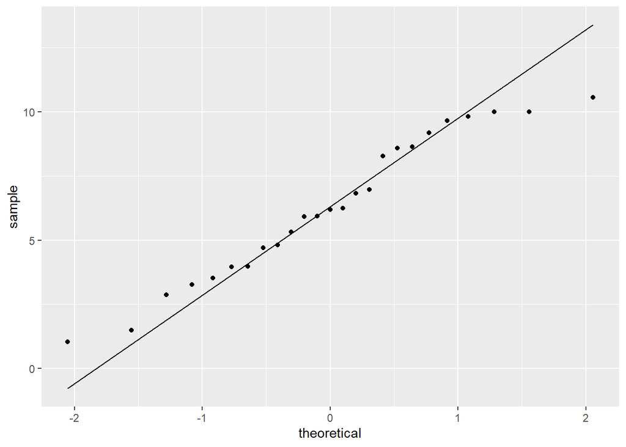

```r
ggplot(data = m1, aes(sample=m1$model$y)) + stat_qq() + stat_qq_line()
```

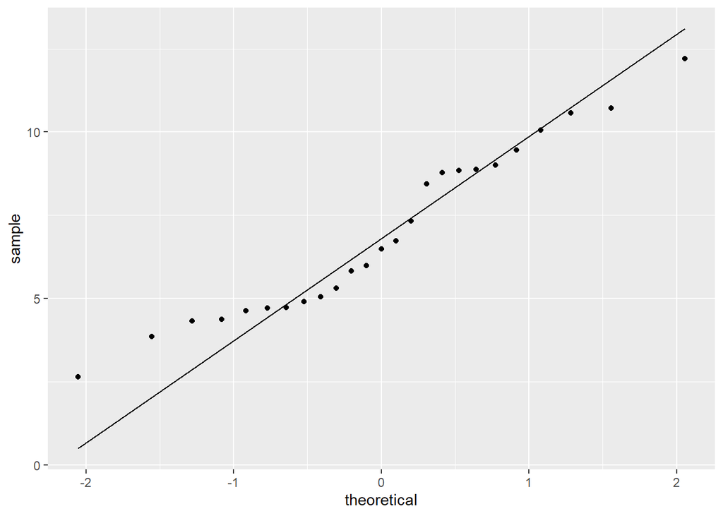

```r
ggplot(data = data_2, aes(sample=y)) + stat_qq() + stat_qq_line()
```

Based on the plots which is true:

- The normality assumption is more suspect for the model fit to data_1.
- The normality assumption is more suspect for the model fit to data_2. - ANSWER

2.Question 2 The above code block has access to two data frames named data_1 and data_2, both with variables y and x. Here, we use y as the response.

Fit a simple linear regression to both datasets. For both fitted regressions, create a Fitted versus Residuals plot.

Based on the plots which is true:

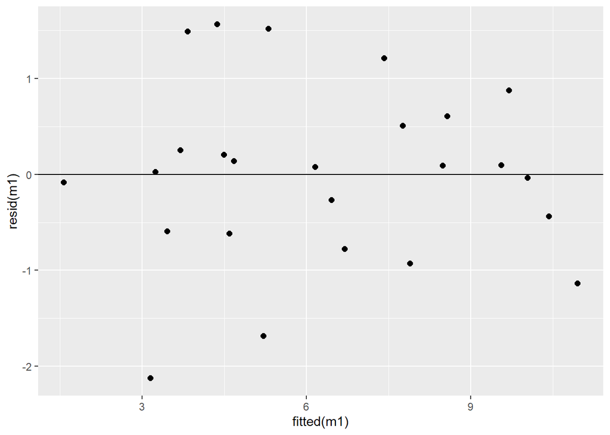

```r
ggplot(data = m1, aes(x = fitted(m1), y = resid(m1))) +
  geom_point(size = 2) + geom_hline(yintercept=0)
```

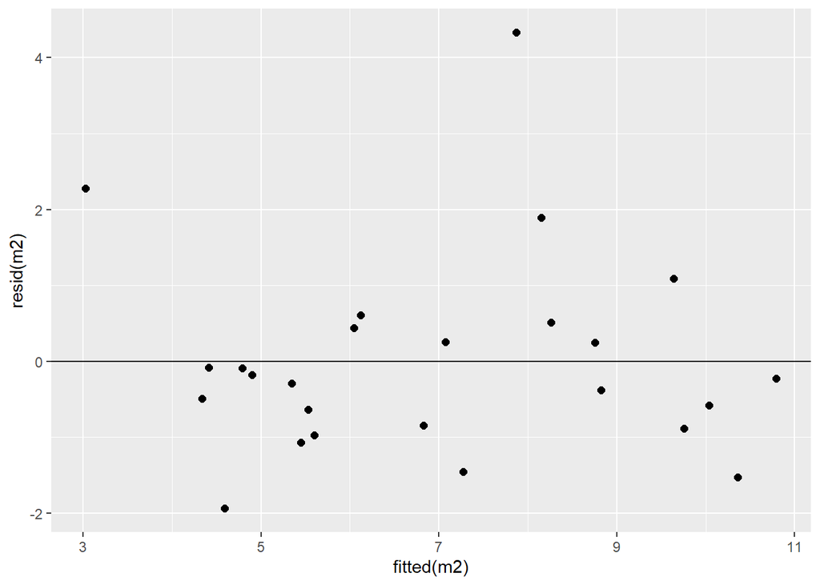

```r
ggplot(data = m2, aes(x = fitted(m2), y = resid(m2))) +
  geom_point(size = 2) + geom_hline(yintercept=0)
```

3.Question 3 Consider the model $Y = 2 + 4 x + \epsilon$ where $\epsilon \sim N(0, \sigma^2 = x ^ 2)$

That is $\text{Var}[Y \mid X = x] = x ^ 2$

Calculate $P[Y < -12 \mid X = -3]$

```r
# fit x=-3 to calculate y
y=2+4*-3
sd=sqrt((-3)^2)
pnorm(-12, mean = y, sd=sd)
```

```
## [1] 0.2524925
```

4.Question 4 For Questions 4-9, use the LifeCycleSavings dataset that is built into R.

Fit a multiple linear regression model with sr as the response and the remaining variables as predictors. What proportion of observations have a standardized residual less than 2 in magnitude?

```r
m <- lm(formula = sr ~ . , data=LifeCycleSavings)
mean(abs(rstandard(m))<2)
```

```
## [1] 0.96
```

5.Question 5

Continue using the model fit in Question 4. Note that each observation is about a particular country. Which country (observation) has the standardized residual with the largest magnitude?

```r
which.max(rstandard(m))
```

```
## Zambia
##     46
```

6.Question 6

Continue using the model fit in Question 4. How many observations have “high” leverage? Use twice the average leverage as the cutoff for “high.”

```r
sum(hatvalues(m)>2*mean(hatvalues(m)))
```

```
## [1] 4
```

7.Question 7

Continue using the model fit in Question 4. Which country (observation) has the largest leverage?

```r
which.max(hatvalues(m))
```

```
## Libya
##    49
```

8.Question 8

Continue using the model fit in Question 4. Report the largest Cook’s distance for observations in this dataset.

```r
max(cooks.distance(m))
```

```
## [1] 0.2680704
```

9.Question 9

Create a subset of the original data that excludes these influential observations and refit the same model to this new data. Report the sum of the estimated $\beta$ coefficients.

```r
influentials <- names(cooks.distance(m)[(cooks.distance(m)>4/nrow(m$model))])
LifeCycleSavings$country <- rownames(LifeCycleSavings)
LifeCycleSavings_wo_influentials <- LifeCycleSavings[!(LifeCycleSavings$country %in% influentials),]
LifeCycleSavings_wo_influentials <- subset(LifeCycleSavings_wo_influentials, select = -c(country) )

m_noinf <- lm(formula = sr ~ . , data = LifeCycleSavings_wo_influentials)
sum(coef(m_noinf))
```

```
## [1] 19.63769
```

10.Question 10 For Questions 10-15, use the airquality dataset that is built into R. For simplicity, we will remove any observations with missing data. We will use Ozone as the response and Temp as a single predictor.

```r
airquality <- na.omit(airquality)
```

$Y = \beta_0 + \beta_1 x + \beta_2 x^2 + \epsilon$ Test for the significance of the quadratic term. Report the p-value of this test.

```r
m <- lm(formula = Ozone~Temp + I(Temp^2), data = airquality)
coef(summary(m))["I(Temp^2)", "Pr(>|t|)"]
```

```
## [1] 0.0004941148
```

11.Question 11 Fit the model

$Y = \beta_0 + \beta_1 x + \beta_2 x^2 + \beta_3 x^3 + \beta_4 x^4 + \epsilon$

Test to compare this model to the model fit in Question 10. Report the p-value of this test.

```r
m2 <- lm(formula = Ozone~ Temp + I(Temp^2) + I(Temp^3) + I(Temp^4), data = airquality)
anova(m, m2)$"Pr(>F)"[2]
```

```
## [1] 0.02436082
```

12.Question 12

Use the Shapiro-Wilk test to asses the normality assumption for the model in Question 11. Use $\alpha = 0.01$ Select the correct decision and interpretation:

```r
shapiro.test(resid(m2))
```

```
##
##  Shapiro-Wilk normality test
##
## data:  resid(m2)
## W = 0.7986, p-value = 5.009e-11
```

- Fail to reject H_0 - Normality assumption is suspect.
- Fail to reject H_0 - Normality assumption is not suspect.
- Reject H_0 - Normality assumption is suspect. - ANSWER
- Reject H_0 - Normality assumption is not suspect.

13.Question 13 Fit the model

$\log(y) = \beta_0 + \beta_1 x + \epsilon$

Use the Shapiro-Wilk test to asses the normality assumption for this model. Use $\alpha = 0.01$

```r
m3 <- lm(formula = log(Ozone)~Temp, data = airquality)
shapiro.test(resid(m3))
```

```
##
##  Shapiro-Wilk normality test
##
## data:  resid(m3)
## W = 0.97667, p-value = 0.04867
```

Select the correct decision and interpretation:

- Fail to reject H_0 - Normality assumption is suspect.
- Fail to reject H_0 - Normality assumption is not suspect.- ANSWER
- Reject H_0 - Normality assumption is suspect.
- Reject H_0 - Normality assumption is not suspect.

14.Question 14 Use the model from Question 13 to create a 90% prediction interval for Ozone when the temperate is 84 degrees Fahrenheit. Report the upper bound of this interval.

```r
# NOTE THAT YOU HAVE TO CONVERT THE PREDICT BACK INTO EXP
exp(predict(m3, interval = c("prediction"), newdata = data.frame(Temp=c(84)), level = .9))
```

```
##        fit      lwr      upr
## 1 46.33907 17.58325 122.1224
```

15.Question 15 Using the model from Question 13, calculate the ratio of:

- The sample variance of residuals for observations with a fitted value less than 3.5
- The sample variance of residuals for observations with a fitted value greater than 3.5

(While not a formal test for the equal variance assumption, we would hope that this value is close to 1.)

```r
var(m3$residuals[m3$fitted.values<3.5])/var(m3$residuals[m3$fitted.values>3.5])
```

```
## [1] 1.353182
```